# TUTORIAL 2

# PART 1

**Discuss if the Normal distribution is a reasonable model to answer questions about wire current? Make sure to identify the random experiment and the random variable and state any assumptions that you make.**

In this scenario, the random experiment involves measuring the electrical current flowing through the SMA wire. The random variable represents the current measurement, in microamps, through the SMA wire. Assuming complete independence and relying on the Central Limit Theorem, we can expect that with a sufficiently large number of measurements, the data will approximate a normal distribution. As a result, the normal distribution serves as a suitable model for analyzing the wire's current measurements.

# PART 2

**Specify the parameters of the Normal distribution and discuss the shape of the distribution in this example. Plot the standardized normal distribution.**

**Importing the relevant libraries!**

```python
from scipy.stats import norm
import numpy as np
import matplotlib.pyplot as plt
```

**Make the x and y axis data.**

```python
mean = 10
stdev = np.sqrt(2)

x = np.linspace(mean - 4*stdev, mean + 4*stdev, int(1e+5))
y = norm.pdf(x, mean, stdev)
```

**Plot the data.**

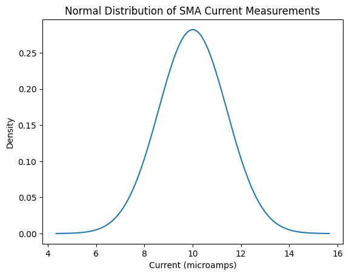

```python
plt.plot(x, y)
plt.xlabel('Current (microamps)')
plt.ylabel('Density')
plt.title('Normal Distribution of SMA Current Measurements')
plt.show()
```

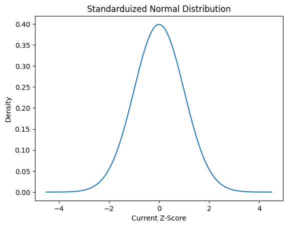

```python
x = np.linspace(-4.5, 4.5, int(1e+5))
y = norm.pdf(x, 0, 1)
plt.plot(x, y)
plt.xlabel('Current Z-Score')
plt.ylabel('Density')
plt.title('Standarduized Normal Distribution')
plt.show()
```

# PART 3

**What is the probability that a randomly selected measurement will exceed 13 microamperes? (i.e. Find P(X>13). You are finding the probability of a certain outcome from a normal population that you have specified.**

**Determine Z-score and probability using Python.**

```python
z = (13 - mean) / stdev
p = norm.sf(z)
p
```

```
0.016947426762344633
```

```python
norm.sf(1.5)
```

```
0.06680720126885807
```

# PART 4

**What is the probability that a current measurement is between 9 and 11 microamperes?**

**State the probability range you are investigating.**

```python
z1 = (9 - mean)/stdev
z2 = (11 - mean)/stdev
p = norm.cdf(z2) - norm.cdf(z1)
p
```

```
0.5204998778130465
```

# PART 5

**Determine the value for which the probability that a current measurement is at or below that value is 0.98.**

**Calculate the Z-score**

```python
p = 0.98
```

```python
z = norm.ppf(p)
```

```python
raw_score = z * stdev + mean
raw_score
```

```
12.904439563124493
```